# Лабораторная работа № 10

Текстовой редактор vi

Чжан Вэньцзюнь

Российский университет дружбы народов

РУДН

2026-10-20

# Информация

## Докладчик

- Чжан Вэньцзюнь
- зачётная книжка № 1132259051
- Российский университет дружбы народов им. П. Лумумбы

## Цель работы

- Знакомство с операционной системой Linux
- Получение практических навыков работы с редактором `vi`
- Освоение режимов работы и команд редактора

## Задание

**Задание 1.** Создать файл `hello.sh` в каталоге `~/work/os/lab06` с помощью `vi`:

```bash
#!/bin/bash
HELL=Hello
function hello {
LOCAL HELLO=World
echo $HELLO
}
echo $HELLO
hello
```

**Задание 2.** Отредактировать файл: заменить `HELL` на `HELLO`, `LOCAL` на `local`, вставить строку `echo $HELLO`, удалить последнюю строку, отменить удаление, сохранить и выйти.

# Выполнение работы

## Режимы редактора vi

- **Командный** — навигация и команды редактирования (после запуска и по `Esc`)
- **Вставки** — ввод текста (`i`, `a`, `o`, `I`, `A`, `O`)
- **Последней строки** — запись, выход, опции (`:`, `/`, `?`)

## Задание 1: создание hello.sh

```bash
mkdir -p ~/work/os/lab06
cd ~/work/os/lab06
vi hello.sh
```

- `i` — переход в режим вставки
- Набран текст скрипта
- `Esc` — возврат в командный режим
- `:wq` + `Enter` — запись и выход
- `chmod +x hello.sh` — файл стал исполняемым

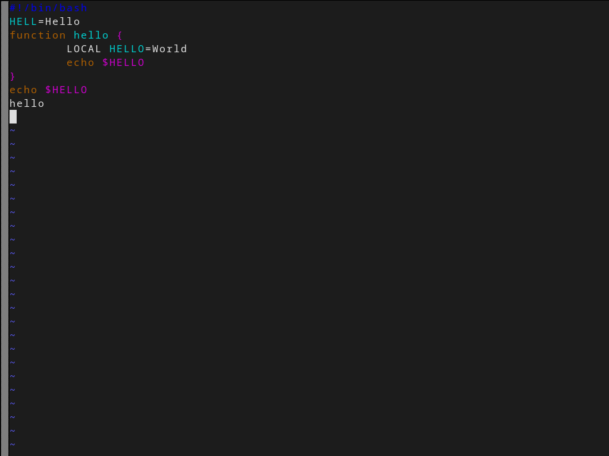

Режим вставки: ввод текста hello.sh

## Задание 2: редактирование файла

| Шаг | Команда | Действие |
| --- | --- | --- |
| 1 | `2G` | переход на вторую строку |
| 2 | `cw` + `HELLO` | замена `HELL` на `HELLO` |
| 3 | `4G`, `dw` | удаление слова `LOCAL` |
| 4 | `i` + `local` | вставка `local` |
| 5 | `G`, `o` | вставка строки ниже |
| 6 | `echo $HELLO` | текст новой строки |
| 7 | `dd` | удаление последней строки |
| 8 | `u` | отмена удаления |
| 9 | `:wq` | запись и выход |

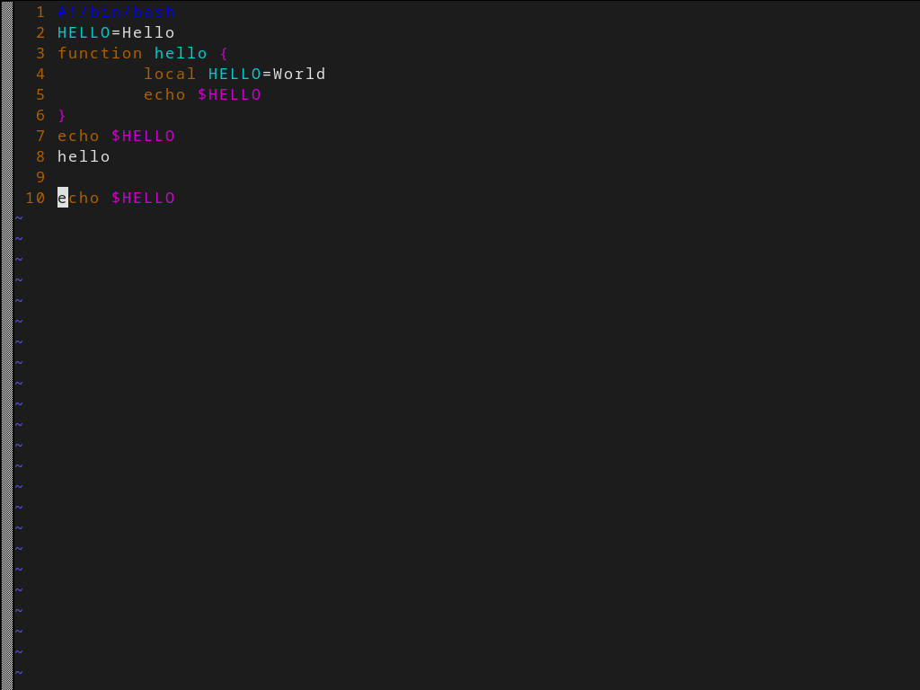

Файл hello.sh после редактирования (:set nu)

## Результат выполнения

```bash
cat hello.sh
./hello.sh
```

```
Hello
World
Hello
```

- `echo $HELLO` вне функции — глобальное `Hello`
- `local HELLO=World` внутри функции — `World`
- последняя строка восстановлена после `dd` и `u`

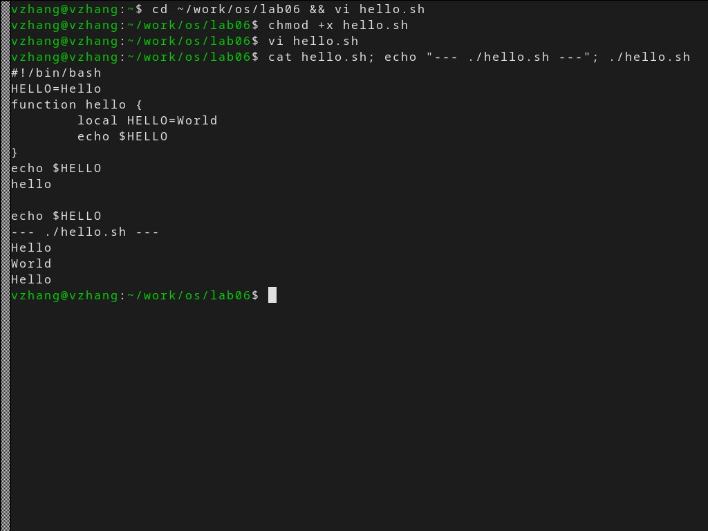

Содержимое файла и результат выполнения

# Заключение

## Выводы

- Изучены три режима работы редактора `vi` и переходы между ними
- Освоены команды управления курсором и позиционирования (`0`, `$`, `G`, `nG`)
- Освоены команды редактирования: вставка, удаление, замена, отмена, буфер
- Освоены команды режима последней строки (`:wq`, `:q!`, `:set nu`)
- Создан и отредактирован исполняемый скрипт `hello.sh`

## Спасибо за внимание!

Вопросы?